# Predicting the effective use of dumbells from sensor data

My aim was to fit a model that can predict how a user is performing dumbbell curls at any point in time given the sensor data

The first step is to load the data and split it into training and validation sets. My analysis uses the caret package to simplying the data setup steps.

```r
library(caret)
exercise_data <- read.csv("../pml-training.csv")
set.seed(2345)
inTrain <- createDataPartition(exercise_data$classe,p=0.6,list=FALSE)
training <- exercise_data[inTrain,]
validation <- exercise_data[-inTrain,]
```

I then removed candidate features that showed little variation across the dataset using the nearZeroVar function from the caret package.

```r
toDrop = nearZeroVar(training)
features <- training[,-toDrop]
```

Because I want to build a model that predicts whether the person is performing the exercise correctly at a point in time rather than over a complete repetion, I next chose to discard the variables that represented a summary statistic over a complete repetition. As these variables only have non-NA values for the “new_window = yes” rows, they are easy to filter out with the fragment of R code shown below. This fragment drops all columns with more than 100 NA values (I chose 100 for safety although actually I could have used > 0 with this dataset as all cases are complete once summary variables are removed.)

```r
summaryValues <- colSums(is.na(features))>100
features <- features[!summaryValues]
```

The final pre-processing step is to drop the columns refering to case numbers, timestamps, users and windows as I am building a model for all users rather than specific users and for a point in time, not a complete repetition.

```r
features  <- features[,7:59]
```

I used the featurePlot function from the caret package and the qplot function from ggplot2 to run some exploratory plots and saw nothing particularly startling. There are a couple of outlier points but nothing that I thought would be signficant given the generous amount of training data avaiable. In the latticed plots below, the colour is the classe label.

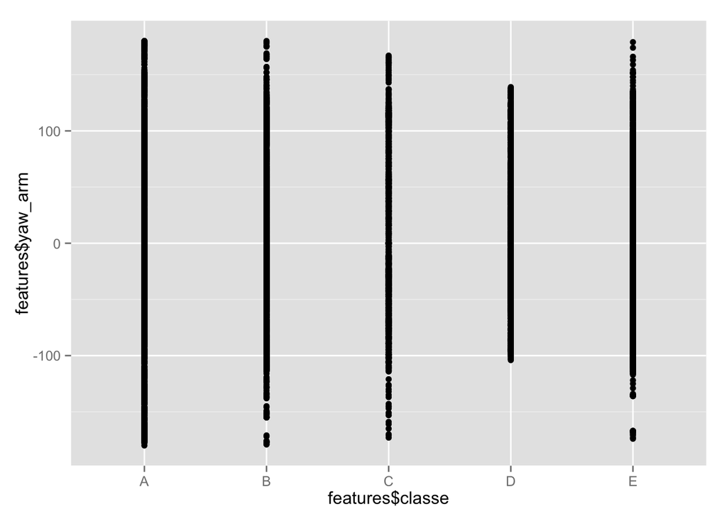

```r
qplot(features$classe,features$yaw_arm)
```

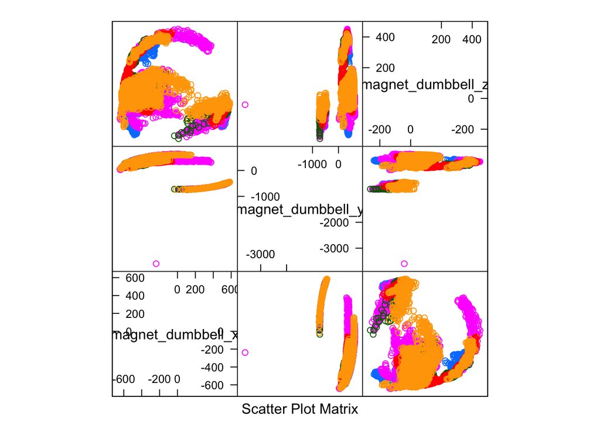

```r
featurePlot(x=features[,c("magnet_dumbbell_x","magnet_dumbbell_y","magnet_dumbbell_z")],
            y = features$classe,
            plot="pairs")
```

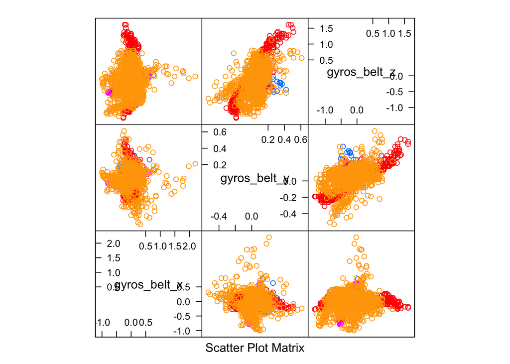

```r
featurePlot(x=features[,c("gyros_belt_x","gyros_belt_y","gyros_belt_z")],
            y = features$classe,
            plot="pairs")
```

```r
##Separates red a bit
```

(There is evidence in a number of plots of clustering that is not explained by the class variable. This is due to the six different test subjects having different motion ranges and styles as can be confirmed by colouring the plots according to user instead of class.)

I chose to use the random forests algorithm as provided by the R package randomForests (as this was much, much faster to train than calling the train function from caret with method = “rf”).

```r
library(randomForest)
modelFit <- randomForest(classe ~ ., data=features)
modelFit
```

```
##
## Call:
##  randomForest(formula = classe ~ ., data = features)
##                Type of random forest: classification
##                      Number of trees: 500
## No. of variables tried at each split: 7
##
##         OOB estimate of  error rate: 0.6%
## Confusion matrix:
##      A    B    C    D    E class.error
## A 3343    4    1    0    0    0.001493
## B   13 2263    3    0    0    0.007021
## C    0   14 2038    2    0    0.007790
## D    0    0   23 1905    2    0.012953
## E    0    0    2    7 2156    0.004157
```

As can be seen above, the model fits the training data extremely well. To estimate the out of sample error and check for overfitting, I then took the withheld validation set, predicted the classes using the fitted model and compared the predictions to the actual classes.

```r
pred <- predict(modelFit,validation)
conMat  <- confusionMatrix(pred,validation$classe)
OOSaccuracy <- conMat$overall[[1]]
OOSaccuracy
```

```
## [1] 0.9924
```

This model accuracy is so good that I did not experiment with using any other algorithms or investigate further pre-processing such as principal component analysis or centering/scaling.

It is also in agreement with the out-of-bag estimates of error rate given by the random forest algorithm (0.6%, see above) When applied to the supplied test cases, the model predicted all 20 correctly.